# midterm

王苡蓁

2019/4/19

# Problem 1.

> (1)在進行回歸分析時，為了避免模型overfitting，也會了對非0的項目進行變數選擇，會在模型加上regularization正規化，也可以說是加上懲罰項（而lasso 與 ridge regression 分別是兩種常用的正規化(regularization)迴歸方法。）。目的在於，有太多非0變項時，可以篩選出其中的比較重要的變項，ridge regression的做法會估計出許多靠近0但非0的係數，也就是說讓beta hat係數逼近0，所以估計圖形呈現的是一個球體；而lasson的做法可以把不重要的變數其係數估計為0，所以可以達到真正篩選變項的目的，lssaon的懲罰項帶有絕對值所以圖形呈現的是正方形。總體來說，ridge實際上就是做了放縮，而lasso實際是做了一個soft thresholding，把很多權重項置0了，所以就能夠得到稀疏的結果。

### 2. 請詳細說明如何使用 K 次交叉驗證(K-folds cross validation)，來對 lasso 之正則化參數(regularization parameter)進行選取。

> (2)在進行lasson的正規化時，首先要考慮的就是懲罰項的λ值。這個λ值要訂多大、多小，可以使用K-folds cross validation來找出最佳的λ值。K-fold cross validation的做法是把資料分成k份，分别使用其中的(k-1)份作為training set ，剩下的1份作cross validation的testing set，最后取最后的平均誤差，來評估這個模型。我們所要做的，就是找到平均誤差最小的項目，也就是最佳的λ值。

# Problem 1.

### 1. 根據 Master 此資料集，已過世的球員中誰的壽命是最長的?

```r
#1-1
library(Lahman)
library(tibble)
library(dplyr)
data("Batting")
data("Master")
data("Salaries")

tbl_Salaries <- tbl_df(Salaries)

tbl_Master<- tbl_df(Master)

m1<-Master %>% select( nameFirst,nameLast,playerID,birthYear,deathYear) %>% na.omit() %>% mutate(.,deathYear-birthYear) %>% arrange(.,desc(deathYear-birthYear))
head(m1)
```

```
  nameFirst  nameLast  playerID birthYear deathYear deathYear - birthYear
1       Red      Hoff  hoffch01      1891      1998                   107
2    Connie   Marrero marreco01      1911      2014                   103
3      Tony Malinosky malinto01      1909      2011                   102
4      Karl   Swanson swanska01      1900      2002                   102
5       Bob    Wright wrighbo01      1891      1993                   102
6      John     Daley daleyjo01      1887      1988                   101
```

```r
ma<-as.matrix(m1)
cat("\n")
```

```r
cat("已過世的球員中誰的壽命是:",m1[1,1],m1[1,2],m1[1,6],"歲")
```

```
已過世的球員中誰的壽命是: Red Hoff 107 歲
```

### 2. 根據 AwardsPlayers 此資料集，請列出獲得 MVP(Most Valuable Player)獎項超過 2次以上(>2)的選手 id。

```r
#1-2
library(Lahman)
data("AwardsPlayers")

m2<-AwardsPlayers %>% filter(.,awardID == "Most Valuable Player") %>% select(.,-yearID,-lgID,-tie,-notes)


m3<-arrange(m2,playerID)%>% select(-awardID)%>% mutate(duplicated(.)) %>% filter(duplicated(.)=="TRUE")

m3
```

```
    playerID duplicated(.)
1  berrayo01          TRUE
2  bondsba01          TRUE
3  bondsba01          TRUE
4  bondsba01          TRUE
5  bondsba01          TRUE
6  bondsba01          TRUE
7  camparo01          TRUE
8  dimagjo01          TRUE
9   foxxji01          TRUE
10 mantlmi01          TRUE
11 musiast01          TRUE
12 pujolal01          TRUE
13 rodrial01          TRUE
14 schmimi01          TRUE
```

### 3. 2016 年仍有上場投球的球員當中(請參考 Pitching)，那一位球員歷年平均薪資(average salary)是最高的?

```r
#1-3
library(Lahman)
data("Pitching")
data("Salaries")
data("Master")

n<-inner_join(Pitching,Salaries,by="playerID")%>%  select(., playerID,yearID.x, salary)%>% filter(yearID.x==2016) %>% arrange(desc(salary))

cat(n[1,1],"的平均薪資最高",n[1,3],"元")
```

[output not shown]

### 4. 根據 Batting 此資料集，2015 年與 2016 年皆有打擊資料的球員有幾位?請使用簡單線性迴歸(simple linear regression)，以 2015 年安打數(H)預測 2016 年安打數。

```r
library(Lahman)
data("Batting")


B2015 <- filter(Batting,yearID=="2015") %>% select(playerID, yearID,H,X2B,X3B,HR,RBI,SH,SF)

B2016 <- filter(Batting,yearID=="2016")%>% select(playerID, yearID,H,X2B,X3B,HR,RBI,SH,SF)

B<-inner_join(B2015,B2016,by="playerID")

B1<-B %>% filter(.,H.x==0, X2B.x==0, X3B.x==0, HR.x==0, RBI.x==0, SH.x==0, SF.x==0,H.y==0, X2B.y==0, X3B.y==0, HR.y==0, RBI.y==0, SH.y==0, SF.y==0)

cat("2015 年與 2016 年皆有打擊資料的球員共有：",length(B1),"個")
```

[output not shown]

```r
lm_fit <- B %>% lm(H.y  ~ H.x, data = .)
summary(lm_fit)
```

```
Call:
lm(formula = H.y ~ H.x, data = .)

Residuals:
     Min       1Q   Median       3Q      Max
-154.037   -6.621   -5.974    2.119  159.859

Coefficients:
            Estimate Std. Error t value Pr(>|t|)
(Intercept)  5.97429    1.01610    5.88 5.26e-09 ***
H.x          0.82324    0.01668   49.36  < 2e-16 ***
---
Signif. codes:  0 '***' 0.001 '**' 0.01 '*' 0.05 '.' 0.1 ' ' 1

Residual standard error: 30.27 on 1265 degrees of freedom
Multiple R-squared:  0.6582,    Adjusted R-squared:  0.6579
F-statistic:  2436 on 1 and 1265 DF,  p-value: < 2.2e-16
```

# Problem3

### 1. 請使用 model.matrix 指令創立一設計矩陣(design matrix)，使其包含除了 quality 之外，所有變項之二階交互作用(two-way interaction)。

```r
#3-1
library(idx2r)
library(nnet)

library(readr)
winequality_red <- read_csv("winequality-red.csv")
winequality_red $quality
```

[output not shown]

[output cut: 33 more lines]

```r
w1<-winequality_red%>% model.matrix(quality ~(.)^2 - 1 ,data=.)
```

### 2.

```r
#3-2
library(glmnet)
set.seed(9487)

winequality_red <- read_csv("winequality-red.csv")
w1<-winequality_red%>% model.matrix(quality ~(.)^2 - 1 ,data=.)

idc_train <- sample(x = c(T, F), size = nrow(w1),
replace = TRUE, prob = c(0.7, 0.3))
lambda_all <- exp(seq(0, -10, length.out = 100))



x<-w1
y<-winequality_red$quality
glmnet_fit <- glmnet(x[idc_train, ], y[idc_train],
                     alpha = 1, lambda = lambda_all,
                     family = "gaussian", standardize = TRUE)



cv_glmnet_fit <- cv.glmnet(x[idc_train, ], y[idc_train], alpha = 1, lambda = lambda_all, family = "gaussian", nfolds = 5, type.measure = "deviance")

cat("獲得參數-最佳lambda： ",cv_glmnet_fit$lambda.min)
```

```
獲得參數-最佳lambda：  0.007086987
```

```r
cat("\n")
```

```r
glmnet_fit%>% predict(s = cv_glmnet_fit$lambda.min, type = "coefficients")
```

```
67 x 1 sparse Matrix of class "dgCMatrix"
                                                         1
(Intercept)                                   2.334966e+01
`fixed acidity`                               .
`volatile acidity`                           -2.560897e-01
`citric acid`                                 .
`residual sugar`                              .
chlorides                                     .
`free sulfur dioxide`                         .
`total sulfur dioxide`                        .
density                                      -1.813104e+01
pH                                            .
sulphates                                     .
alcohol                                       1.557738e-01
`fixed acidity`:`volatile acidity`            .
`fixed acidity`:`citric acid`                 .
`fixed acidity`:`residual sugar`              .
`fixed acidity`:chlorides                     .
`fixed acidity`:`free sulfur dioxide`         .
`fixed acidity`:`total sulfur dioxide`        .
`fixed acidity`:density                       .
`fixed acidity`:pH                            1.131088e-03
`fixed acidity`:sulphates                     .
`fixed acidity`:alcohol                       .
`volatile acidity`:`citric acid`              .
`volatile acidity`:`residual sugar`           .
`volatile acidity`:chlorides                 -5.120040e-01
`volatile acidity`:`free sulfur dioxide`      .
`volatile acidity`:`total sulfur dioxide`     5.135271e-03
`volatile acidity`:density                   -4.455857e-02
`volatile acidity`:pH                        -2.186659e-01
`volatile acidity`:sulphates                  .
`volatile acidity`:alcohol                    .
`citric acid`:`residual sugar`                .
`citric acid`:chlorides                       .
`citric acid`:`free sulfur dioxide`           .
`citric acid`:`total sulfur dioxide`          .
`citric acid`:density                         .
`citric acid`:pH                              .
`citric acid`:sulphates                      -1.605415e-02
```

[output cut: 14 more lines]

```
`free sulfur dioxide`:`total sulfur dioxide`  .
`free sulfur dioxide`:density                 .
`free sulfur dioxide`:pH                      .
`free sulfur dioxide`:sulphates               .
`free sulfur dioxide`:alcohol                 2.649466e-04
`total sulfur dioxide`:density                .
`total sulfur dioxide`:pH                     .
`total sulfur dioxide`:sulphates             -7.544252e-03
`total sulfur dioxide`:alcohol                .
density:pH                                   -4.936527e-01
density:sulphates                             .
density:alcohol                               .
pH:sulphates                                  .
pH:alcohol                                    .
sulphates:alcohol                             1.560548e-01
```

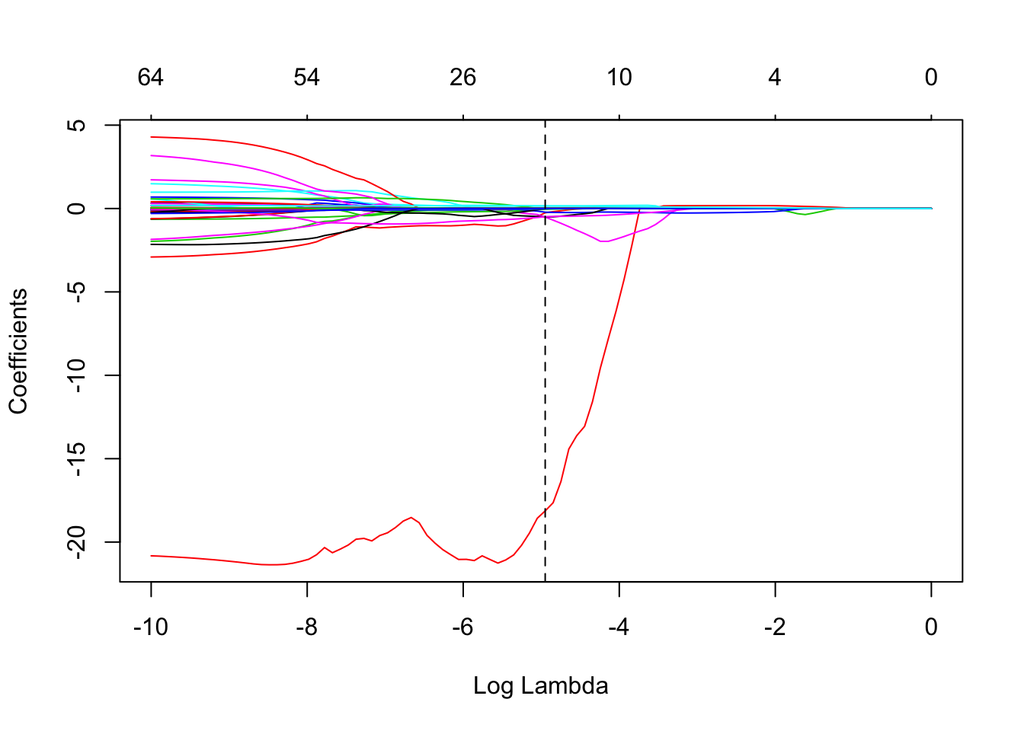

```r
glmnet_fit%>% plot(xvar = "lambda")
abline(v = log(cv_glmnet_fit$lambda.min), lty = 2)
```

### 3.

```r
#3-3
#k-fold CV
library(kknn)

winequality_red <- read_csv("winequality-red.csv")
w1<-winequality_red%>% model.matrix(quality ~(.)^2 - 1 ,data=.)


cv_glm3 <- cv.glmnet(w1[idc_train, ], winequality_red$quality[idc_train], alpha = 1, lambda = lambda_all, family = "gaussian", nfolds = 10, type.measure = "deviance")


cat("最適切之懲罰強度 : ", cv_glm3$lambda.min)
```

```
最適切之懲罰強度 :  0.003494498
```

```r
cat("\n")
```

### 4.

```r
y_hat_test <- cv_glm3 %>% predict(s = cv_glm3$lambda.min, newx = w1[!idc_train,], type = "link")

R<-1 - mean((winequality_red$quality[!idc_train] - y_hat_test)^2) /var(winequality_red$quality[!idc_train])

cat("R-square:" ,R)
```

```
R-square: 0.4126092
```

### 5.

```r
#3-5 告最佳模型下，迴歸係數不為零之共變量(covariate)與其係數估計
cv_glm3 %>% predict(s = cv_glm3$lambda.min, type = "coefficients") %>% "["(., which(. !=0), )
```

```
                                 (Intercept)
                                2.689051e+01
                          `volatile acidity`
                               -1.013763e+00
                                     density
                               -2.104627e+01
                                     alcohol
                                1.434194e-01
          `fixed acidity`:`volatile acidity`
                               -6.640848e-03
                   `fixed acidity`:chlorides
                               -2.745809e-02
                          `fixed acidity`:pH
                                5.981287e-03
   `volatile acidity`:`total sulfur dioxide`
                                8.078103e-03
                  `volatile acidity`:density
                               -1.776958e-01
        `citric acid`:`total sulfur dioxide`
                                3.092965e-03
                     `citric acid`:sulphates
                               -4.069917e-01
                  `residual sugar`:chlorides
                                3.077441e-01
      `residual sugar`:`free sulfur dioxide`
                                1.224763e-03
                    `residual sugar`:alcohol
                               -4.719576e-03
             chlorides:`free sulfur dioxide`
                               -7.328151e-02
            chlorides:`total sulfur dioxide`
                               -1.653056e-02
                         chlorides:sulphates
                               -1.191625e-01
                           chlorides:alcohol
                               -1.649624e-02
`free sulfur dioxide`:`total sulfur dioxide`
                               -1.041876e-05
             `free sulfur dioxide`:sulphates
                               -2.081623e-05
               `free sulfur dioxide`:alcohol
                                7.274060e-04
            `total sulfur dioxide`:sulphates
                               -1.070265e-02
                                  density:pH
                               -6.935886e-01
                           sulphates:alcohol
                                1.860431e-01
```